# POLI 361

October 31, 2018

## Media and Violence

### Persuasion and Coordination

## Social Media and Violence

### **Persuasion**

"Echo chambers" alter empirical credibility, messenger credibility

- what is "True"? what sources are "Fake news?
- Algorithms direct people toward more resonant frames

Changing salience:

- network makes certain values seem more relevant to reality

More extreme frames

## Social Media and Violence

### **Coordination**

Ability to organize violence

- Easier to meet online than in person, build network rapidly

Changing cost of action:

- Social pressure (within social network) to do violence
- Supportive voices offsets risk of condemnation

## Social Media and Violence

### Facebook exposure causes anti-Refugee violence in Germany

- How big is this effect?
- What kinds of violence does it affect?
- How does it work?

[video not shown]

## Radio in Rwanda and Germany

### Rwanda:

Radio and coordination

### Germany:

Radio and persuasion

## Rwandan Genocide: Background

- Colonial Origins of Hutu/Tutsi divide
- Independence created political struggle
- Civil War in 1980s, Tutsi armed group
- Breakdown of peace process in 1993-4

## Rwandan Genocide: Radio

### RTLM

- Government-run radio station

### Framing

**Diagnostic frames**:

- Emphasized RPF (Tutsi armed group) atrocities
- Alleged local Tutsis involved in conspiracy to dominate Hutus
- Dehumanized Tutsis as "cockroaches"

**Prognostic frames**:

- Preemptive violence necessary for "self-defense"

## Rwandan Genocide: Question

### Did radio endorsement of violence cause violence?

### Was it persuasion? Coordination?

## Rwandan Genocide: Question

**Some intuitions**:

### Persuasion

Violence perpetrated by **individuals** could be **coordination** or **persuasion**

### Coordination

Violence perpetrated **collectively** likely **coordination**

exponential effects suggest **coordination** rather than **persuasion**

"Spill-over"/"neighboorhood" effects of radio suggest **coordination**

## Rwandan Genocide: Difficulty

### Selection Effects

Radio transmitters built by government…

built in places with disposition toward violence?

## Solution:

### Examine Exposure to Radio

- after accounting for distance from transmitter
- variation within local districts

Exposure to radio **arbitrarily disrupted** by local hills/mountains

## Elevation and Radio Signal

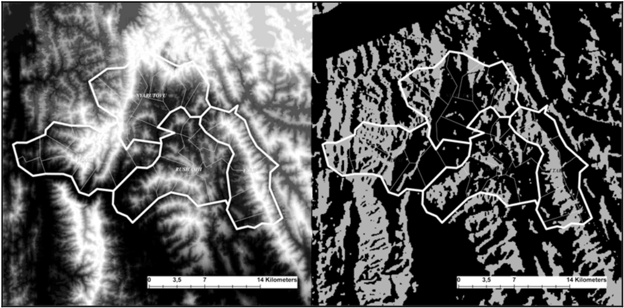

## Rwanda: Effects of Radio (RTLM)

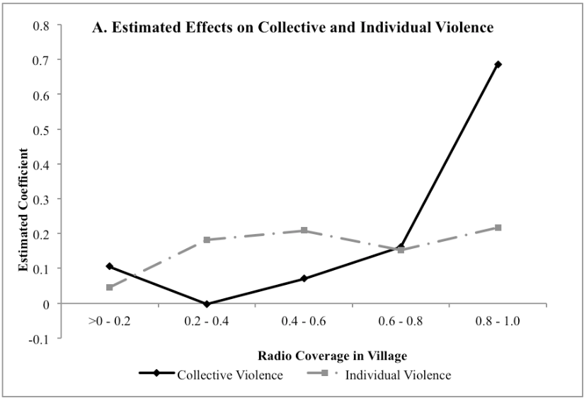

## Rwanda: Effects of Radio (RTLM)

Moderate increase in individual violence

**could be coordination**

- government endorsement of violence reduces costs for individuals

**could be persuasion:**

- convinced by threat posed by Tutsi/dehumanization

## Rwanda: Effects of Radio (RTLM)

### **Coordination**:

#### Increase in collective violence at high radio exposure

- shift to violence that requires planning and cooperation
- non-linear… more people join after first people participate

#### Spillovers:

More violence in village if **neighboring villages** have radio exposure

- coordination, not persuasion… because spillovers amplify local radio effects, not offset

## Inter-war Germany

## Nazi-Era Radio:

### Did exposure to the radio increase violence against Jews?

Examine two time periods:

- 1928-1932 (Moderate control over radio)
- 1933-1938 (Nazi control over radio)

## Effects

### Changes in Radio Messages

- Anti-Nazi radio reduced Nazi membership, anti-Semitic harassment
- Pro-Nazi radio exposure increased Nazi Membership, anti-Semitic harassment

## Effects

### Persuasion or Coordination?

1. **No effects** on attacks on synagogues (more coordination required)
2. Exposure to radio **caused** more denunciations of Jews, open letters to Nazi newspapers (individual actions)

## Effects

### Persuasion or Coordination?

1. Opposite effects of Nazi radio in places with different histories of anti-Semitism

14th century pogroms against Jews predict Nazi-era violence, and

- Radio exposure **increased** anti-Semitism in places with medieval anti-Jewish pogroms
- Radio exposure **decreased** anti-Semitism in places without medieval anti-Jewish pogroms

## Effects

### Must be Persuasion and *Dissuasion*

- Resonance and lack of Resonance drive different responses
- Most effects on individual-level behavior